# R you Ready ? Visualizing in R Practice Answer Key

ggplot Basics

## Overview

This worksheet is meant to serve as a worksheet to practice using ggplot following the grammar of graphics structure. If you have any questions, please feel free to contact Ketura Elie at ane48@pitt.edu.

## Iris Dataset

For this worksheet, you’ll be working with the Iris dataset (which is already built into R so nothing to load or read in)

```r
iris %>% glimpse()
```

```
## Rows: 150
## Columns: 5
## $ Sepal.Length <dbl> 5.1, 4.9, 4.7, 4.6, 5.0, 5.4, 4.6, 5.0, 4.4, 4.9, 5.4, 4.…
## $ Sepal.Width  <dbl> 3.5, 3.0, 3.2, 3.1, 3.6, 3.9, 3.4, 3.4, 2.9, 3.1, 3.7, 3.…
## $ Petal.Length <dbl> 1.4, 1.4, 1.3, 1.5, 1.4, 1.7, 1.4, 1.5, 1.4, 1.5, 1.5, 1.…
## $ Petal.Width  <dbl> 0.2, 0.2, 0.2, 0.2, 0.2, 0.4, 0.3, 0.2, 0.2, 0.1, 0.2, 0.…
## $ Species      <fct> setosa, setosa, setosa, setosa, setosa, setosa, setosa, s…
```

## Data Types

First, identify the data type for each variable (there are five).  
*Hint*: You can use `str()` to display structure of the iris dataset

```r
str(iris)
```

```
## 'data.frame':    150 obs. of  5 variables:
##  $ Sepal.Length: num  5.1 4.9 4.7 4.6 5 5.4 4.6 5 4.4 4.9 ...
##  $ Sepal.Width : num  3.5 3 3.2 3.1 3.6 3.9 3.4 3.4 2.9 3.1 ...
##  $ Petal.Length: num  1.4 1.4 1.3 1.5 1.4 1.7 1.4 1.5 1.4 1.5 ...
##  $ Petal.Width : num  0.2 0.2 0.2 0.2 0.2 0.4 0.3 0.2 0.2 0.1 ...
##  $ Species     : Factor w/ 3 levels "setosa","versicolor",..: 1 1 1 1 1 1 1 1 1 1 ...
```

## Visualizing 2 variables

### Basic Plot

Create a basic scatter plot with `Sepal.Length` on the x-axis and `Sepal.Width` on the y-axis. The code has been started for you. Include the appropriate mapping the in the parent call and choose the appropriate geom to create the scatter plot.

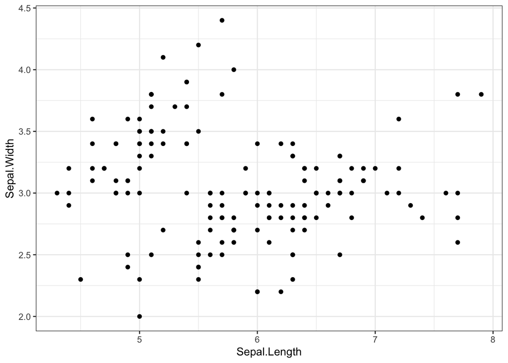

```r
iris %>%
  ggplot(aes(x = Sepal.Length, y = Sepal.Width)) +
  geom_point() +
  theme_bw()
```

### Color

Now change the color of the points to blue.

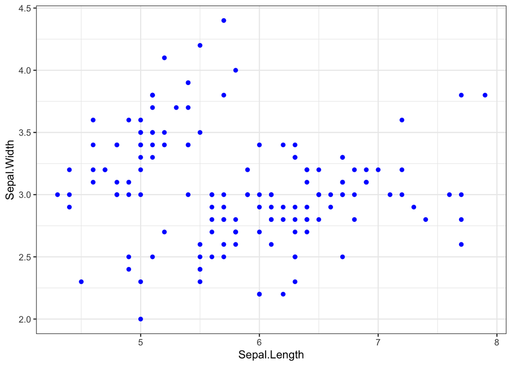

```r
iris %>%
  ggplot(aes(x = Sepal.Length, y = Sepal.Width)) +
  geom_point(color = "blue") +
  theme_bw()
```

Now change the color of the points to pink.

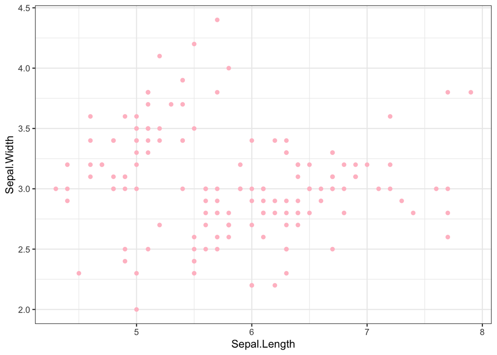

```r
iris %>%
  ggplot(aes(x = Sepal.Length, y = Sepal.Width)) +
  geom_point(color = "pink") +
  theme_bw()
```

Now we’ll be working with `aes()` within the geom call. Use `aes()` within the appropriate layer to map color the `Sepal.Length` variable.

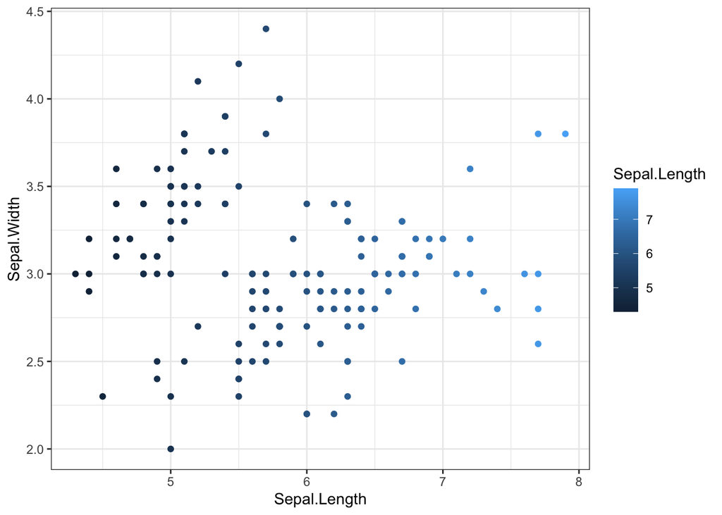

```r
iris %>%
  ggplot(aes(x = Sepal.Length, y = Sepal.Width)) +
  geom_point(aes(color = Sepal.Length)) +
  theme_bw()
```

*Does this change the information communicated in the plot compared to hard coding the color of the points?*

Use `aes()` within the appropriate layer to map color the `Sepal.Width` variable.

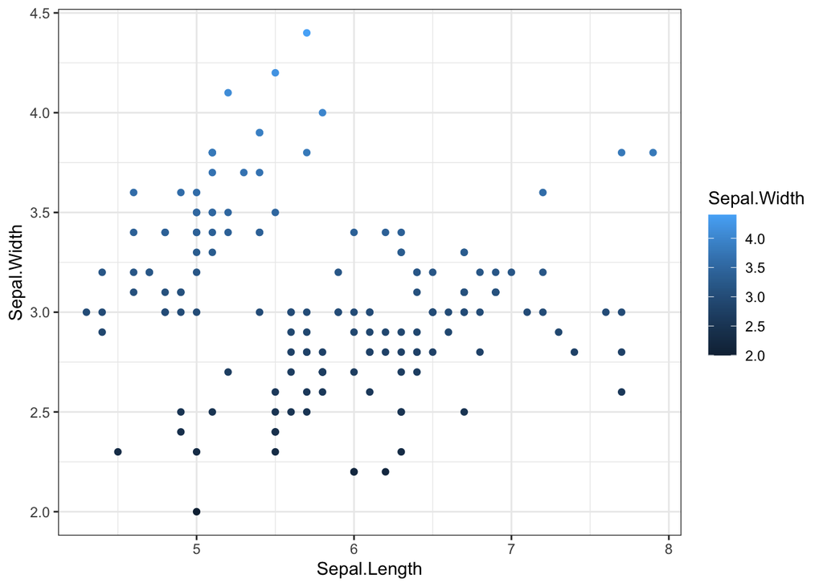

```r
iris %>%
  ggplot(aes(x = Sepal.Length, y = Sepal.Width)) +
  geom_point(aes(color = Sepal.Width)) +
  theme_bw()
```

### Size and Opacity

Now change the size of the points to 3.5 and the opacity (or transparency) of the points to .75!  
*Hint*: Think about what we are changing about our plot (the geom) to determine which layer `size` and `alpha` should be in.

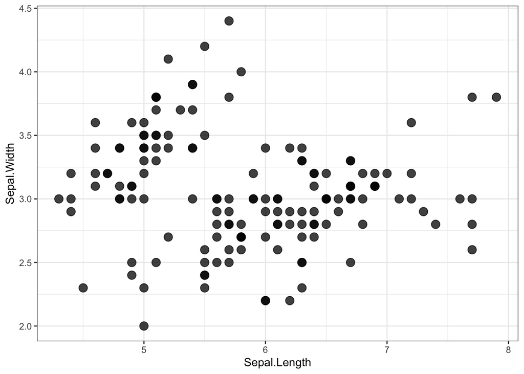

```r
iris %>%
  ggplot(aes(x = Sepal.Length, y = Sepal.Width)) +
  geom_point(size = 3.5,
             alpha = .75) +
  theme_bw()
```

Now map the size of the points to `Sepal.Width` and the opacity to `Sepal.Length`

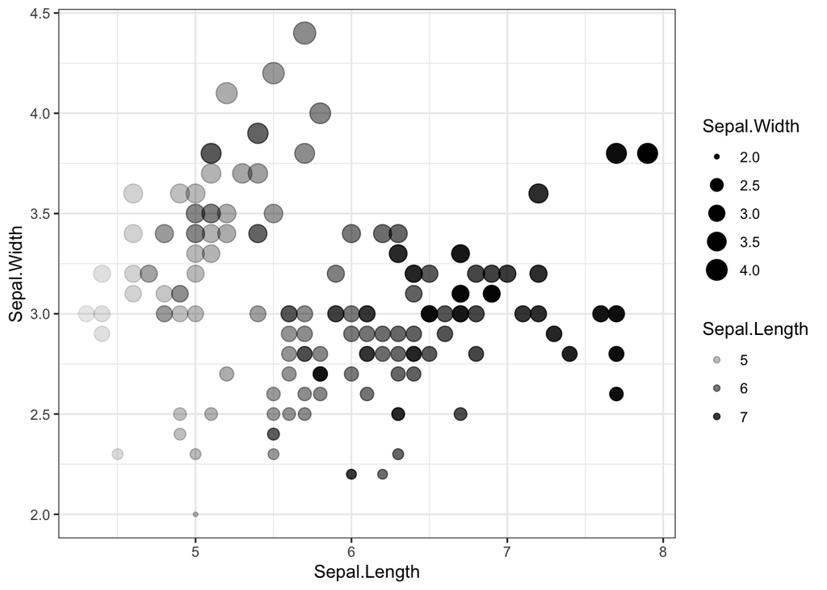

```r
iris %>%
  ggplot(aes(x = Sepal.Length, y = Sepal.Width)) +
  geom_point(aes(size = Sepal.Width,
                 alpha = Sepal.Length)) +
  theme_bw()
```

We don’t know any other variables, only see 2 that we are plotting.

What is general relationship between these two variables?

## Visualizing 3 Variables

Let’s see if the relationship you described between `Sepal.Length` and `Sepal.Width` changes by adding another variable to our visualization.

Remember that how we visualize variables depends on the variable type. Our third variable will be `Species`.

1. What is the variable type for `Species`? **Factor!**
2. Base on the variable type, what aesthetic would be the most appropriate to use to visualize `Species`? **We can use color and shape as the factor only has 3 levels so we won’t exhaust the color and shape options. You can think of factors as categorical variables (or similar to them) and the same way we would visualize a categorical variable is the same way we can visualize factors!**

Create a plot visualizing all 3 variables! `Sepal.Length` on the x-axis, `Sepal.Width` on the y-axis, and `Species` as the aesthetic you listed in question 2.

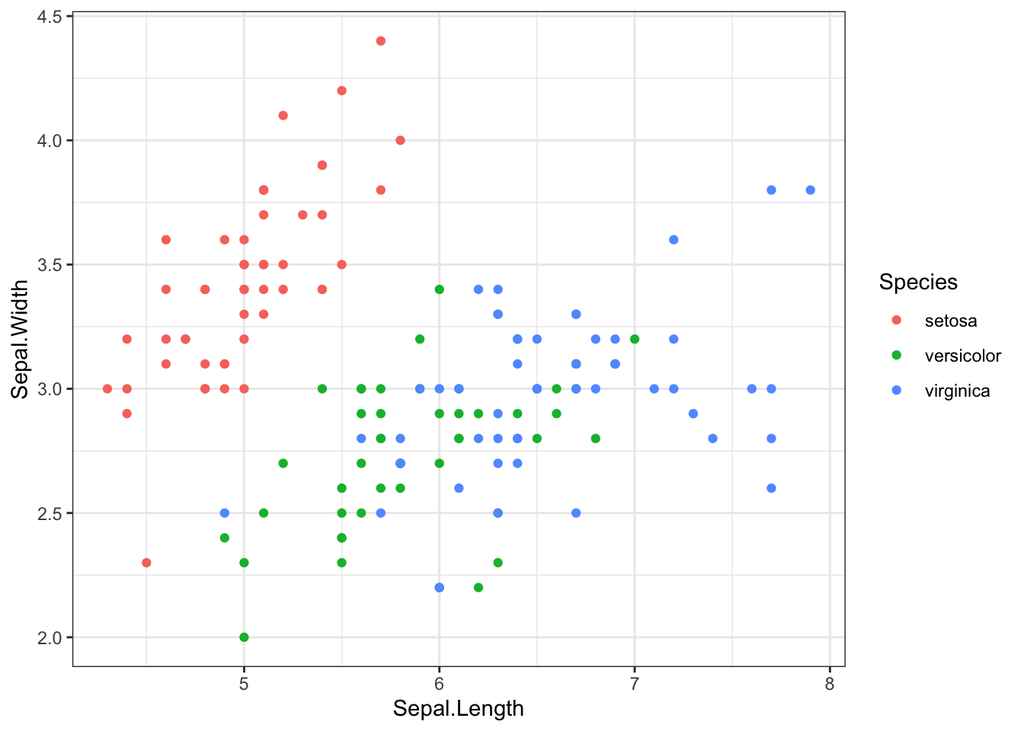

```r
## using color to visualize species
iris %>%
  ggplot(aes(x = Sepal.Length, y = Sepal.Width)) +
  geom_point(aes(color = Species)) +
  theme_bw()
```

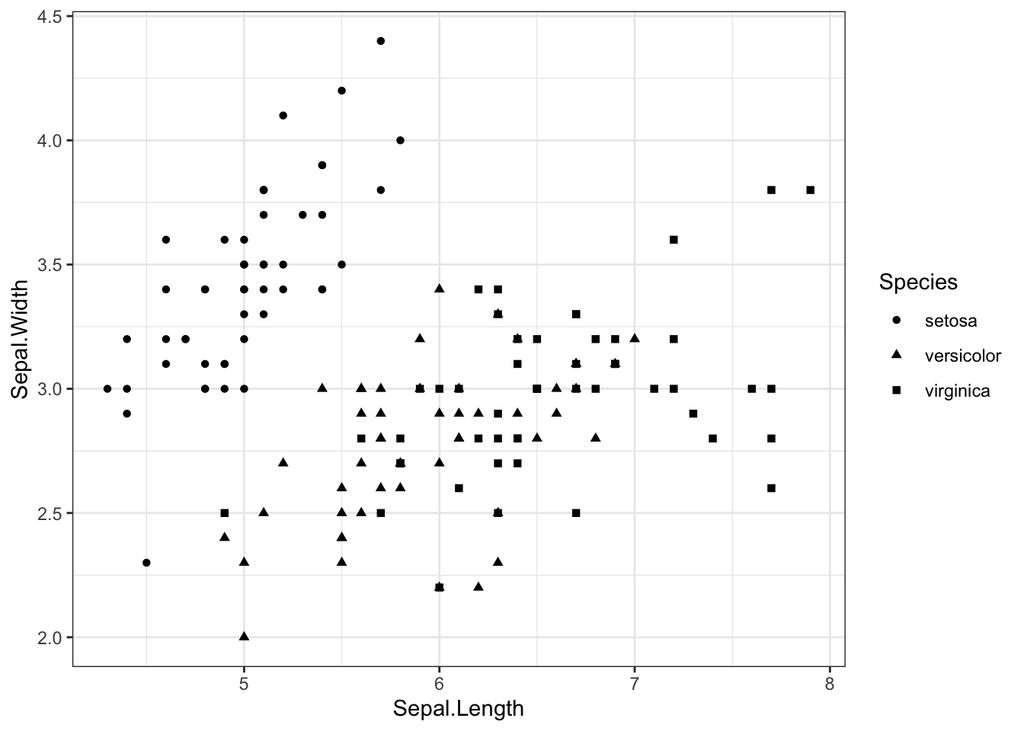

```r
## using shape to visualize species
iris %>%
  ggplot(aes(x = Sepal.Length, y = Sepal.Width)) +
  geom_point(aes(shape = Species)) +
  theme_bw()
```

#### We can use both color and shape to visualize species

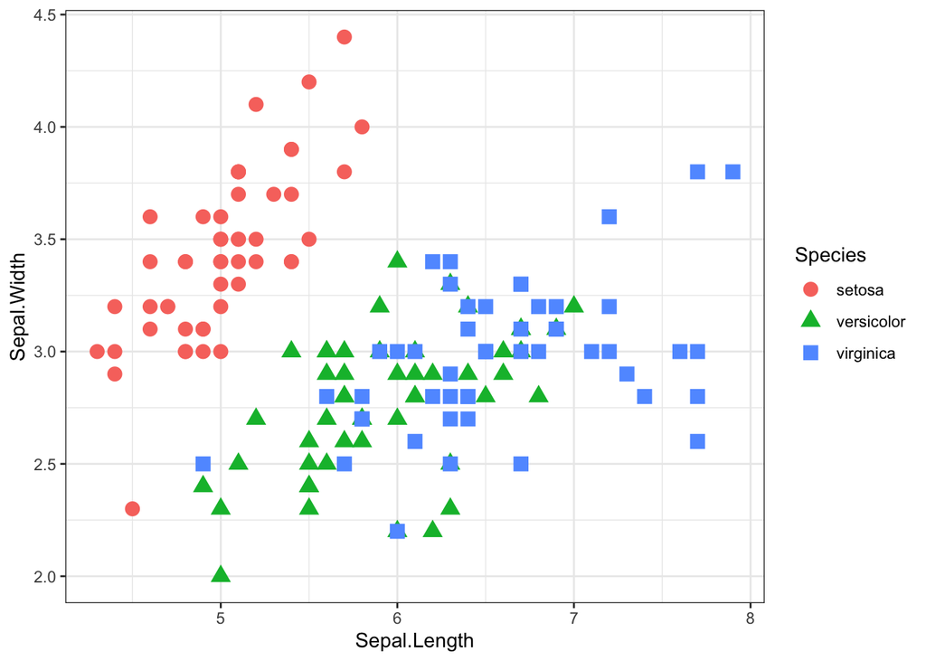

```r
iris %>%
  ggplot(aes(x = Sepal.Length, y = Sepal.Width)) +
  geom_point(aes(color = Species,
                 shape = Species),
             size = 3.5 ) + ## making the points bigger
  theme_bw()
```

How would you describe the relationship between `Sepal.Length` and `Sepal.Width` now that `Species` is included? We can see that the relationship between Sepal.Length and Sepal.Width is moderated by Species in that different species cluster together.

## Visualizing Trends

The final portion of this worksheet briefly covers visualizing trends (aka statistical relationships)

### 2 variables

Run the code chunk to show relationship between `Sepal.Length` and `Sepal.Width`

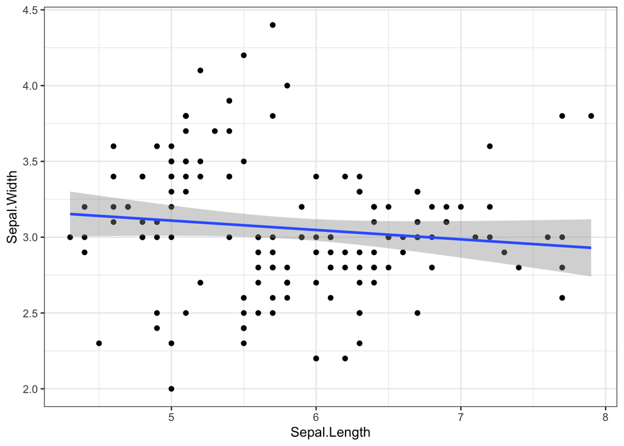

```r
iris %>%
    ggplot(mapping = aes(x = Sepal.Length, y = Sepal.Width)) +
    geom_point() +
    geom_smooth(formula = y ~ x,
                method = lm) +
    theme_bw()
```

Here we are using `geom_smooth` to plot a regression line through our scatter plot. We know that it is a regression line from the `method = lm` call (where lm stands for linear model) and from the `formula = y ~ x`, which is standard R code to say we are regression y on x (the `~` (tilda) here means “as a function of”).

Similar to other geoms, we can change the aesthetics of the this line manually (or hard-coding).

Let’s change the color of the line to yellow!

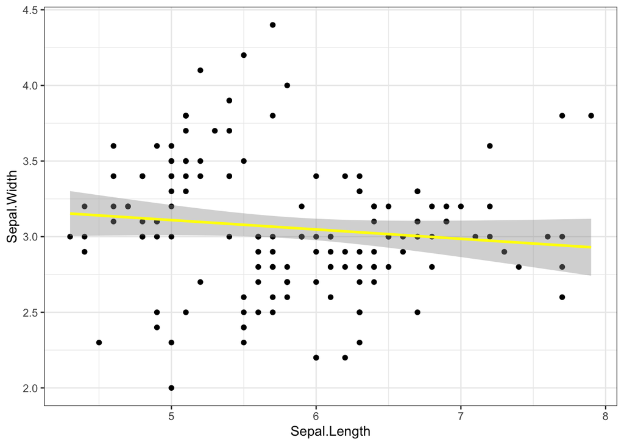

```r
iris %>%
    ggplot(mapping = aes(x = Sepal.Length, y = Sepal.Width)) +
    geom_point() +
    geom_smooth(formula = y ~ x,
                method = lm,
                color = "yellow") +
    theme_bw()
```

The grey band that you see around the line is the confidence interval of our regression line, and we can change the color of this as well! Since it is a “3D” object, we have to use `fill` as our aesthetic (rather than `color`)

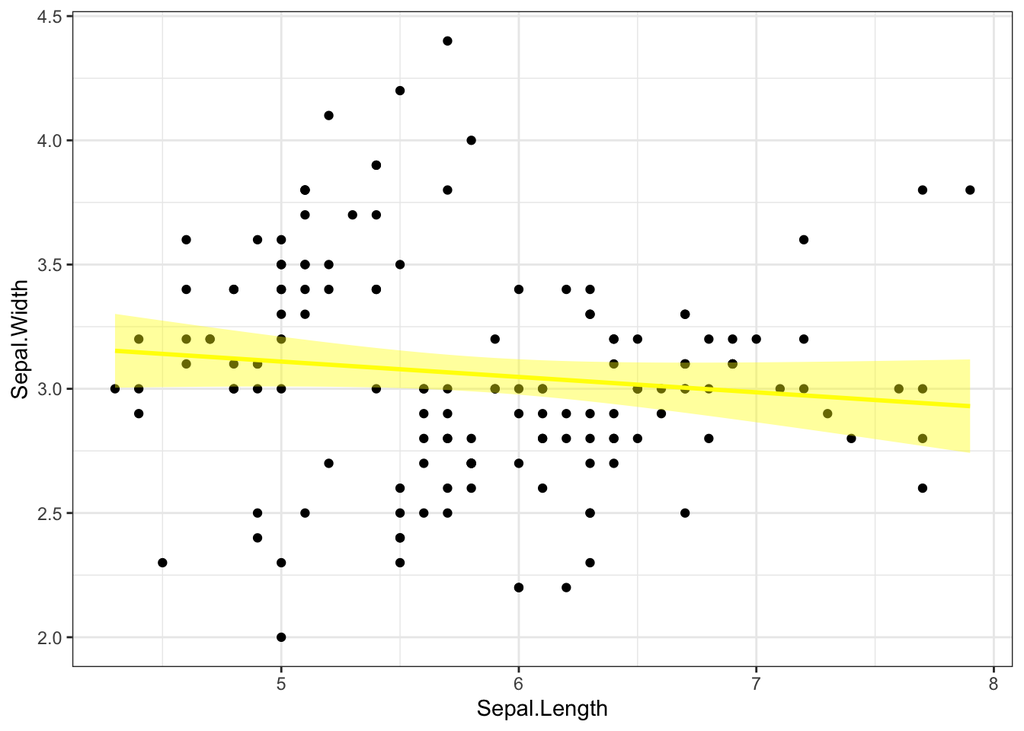

```r
iris %>%
    ggplot(mapping = aes(x = Sepal.Length, y = Sepal.Width)) +
    geom_point() +
    geom_smooth(formula = y ~ x,
                method = lm,
                color = "yellow",
                fill = "yellow") +
    theme_bw()
```

To highlight how visualizations can be bias, let’s see the regression line without the data (aka our points) and the confidence interval.

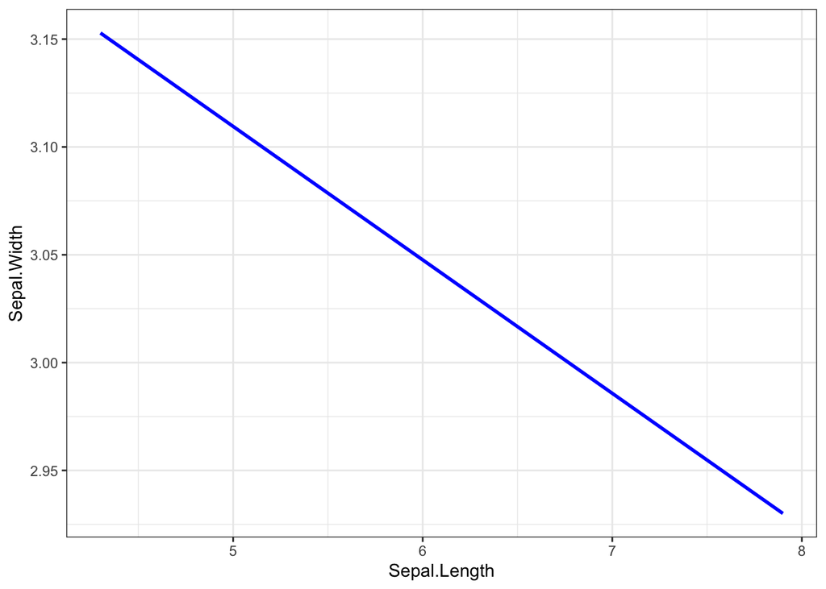

```r
iris %>%
    ggplot(mapping = aes(x = Sepal.Length, y = Sepal.Width)) +
    geom_smooth(formula = y ~ x,
                method = lm,
                color = "blue",## changing the color
                se = FALSE) +  ## and taking away our confidence interval
    theme_bw()
```

So let’s create a visualization that is more accurate to our data!

Starting with the basic scatter plot again.

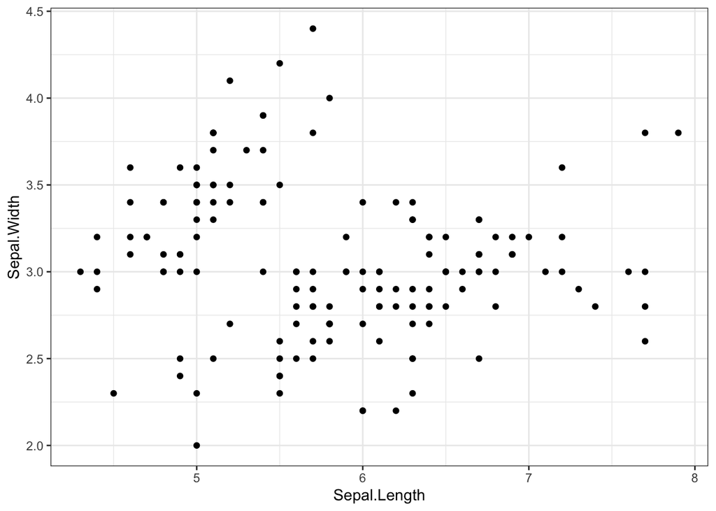

```r
iris %>%
    ggplot(mapping = aes(x = Sepal.Length, y = Sepal.Width)) +
    geom_point() +
    theme_bw()
```

Now let’s add our line

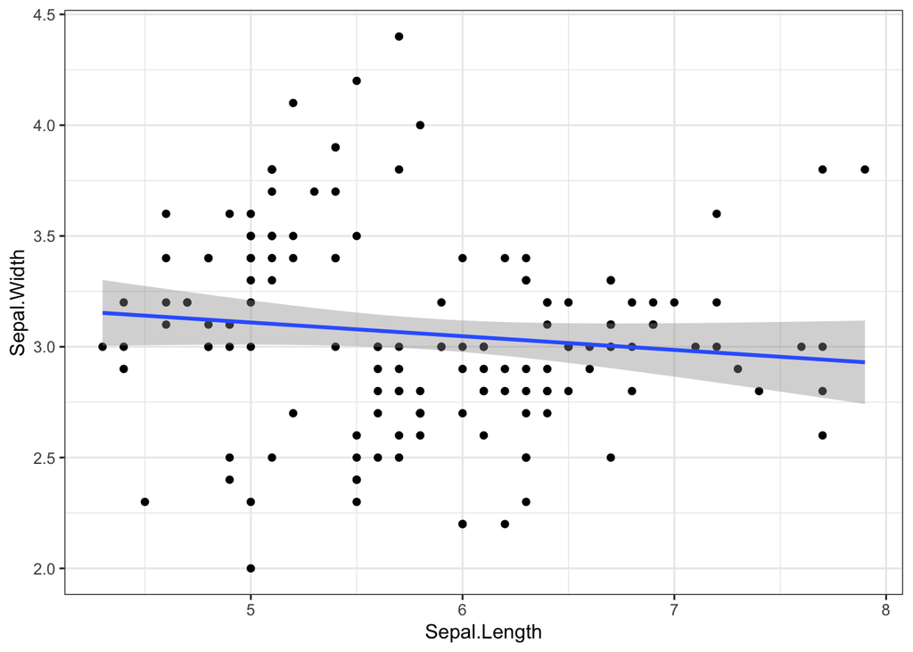

```r
iris %>%
    ggplot(mapping = aes(x = Sepal.Length, y = Sepal.Width)) +
    geom_point() +
    geom_smooth(formula = y~x,
                method = lm) +
    theme_bw()
```

### 3 Variables

We know that `Species` changes how `Sepal.Length` and `Sepal.Width` relate to each other (from our previous plots) so let’s map it to the color aesthetic of the points. The code chunk has been started for you.

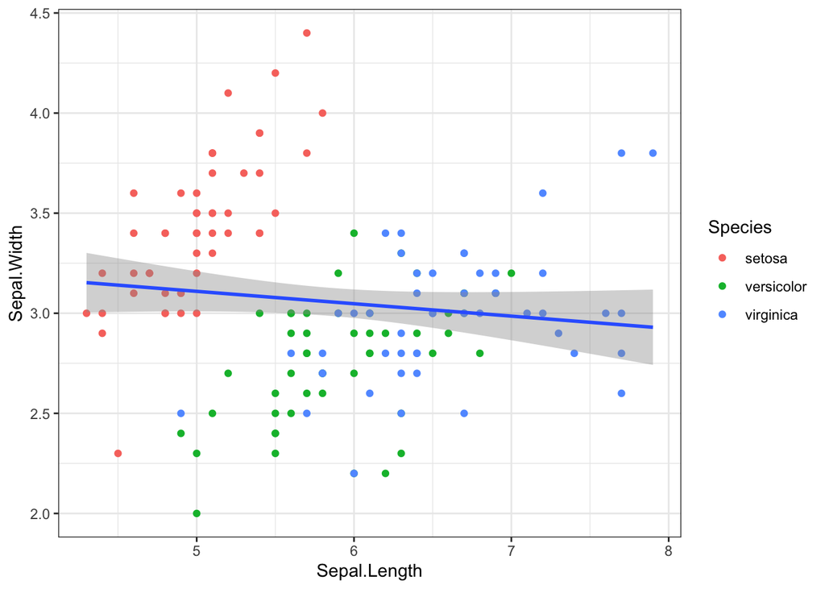

```r
## CHANGE eval to equal TRUE once you completed the code
iris %>%
    ggplot(mapping = aes(x = Sepal.Length, y = Sepal.Width)) +
    geom_point(mapping = aes(color = Species)) +
    geom_smooth(formula = y~x,
                method = lm) +
    theme_bw()
```

Similar to other geoms, we can also map the aesthetics `geom_smooth` to a variable. Let’s map the color of our regression line to `Species`. *Note*: Still include `Species` mapped to the color aesthetic of the points as well.

The code chunk has been started for you.

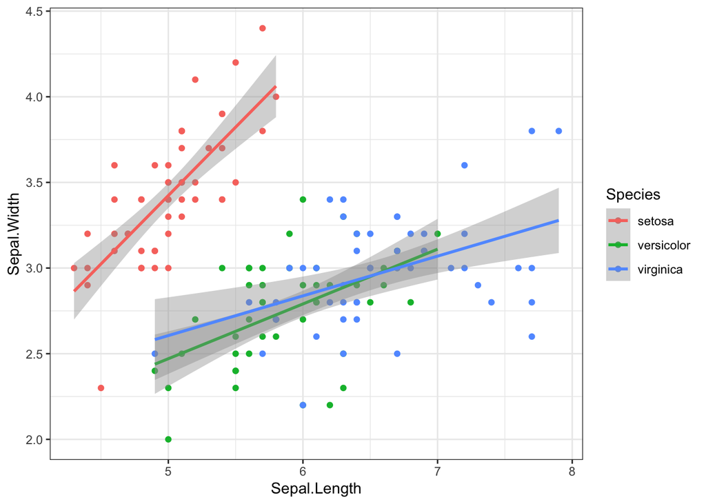

```r
## CHANGE eval to equal to TRUE once you've completed the code chunk
iris %>%
    ggplot(mapping = aes(x = Sepal.Length, y = Sepal.Width)) +
    geom_point(aes(color = Species)) +
    geom_smooth(formula = y~x,
                method = lm,
                mapping = aes(col = Species)) +
    theme_bw()
```

Change the fill of the confidence interval to also be map to the `Species`.

The code chunk has been started for you.

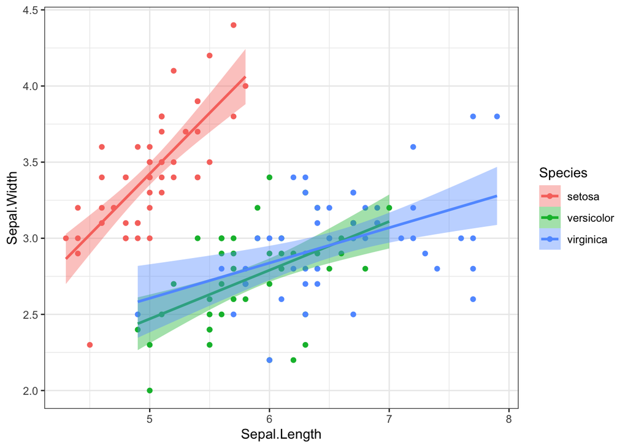

```r
## CHANGE eval to equal to TRUE once you've completed the code chunk
iris %>%
    ggplot(mapping = aes(x = Sepal.Length, y = Sepal.Width)) +
    geom_point(aes(color = Species)) +
    geom_smooth(formula = y~x,
                method = lm,
                mapping = aes(col = Species,
                              fill = Species)) +
    theme_bw()
```

Finally, let’s make the visualization more legible by including facets!. Use `facet_wrap` to show the plot by `Species`.

The code chunk has been started for you.

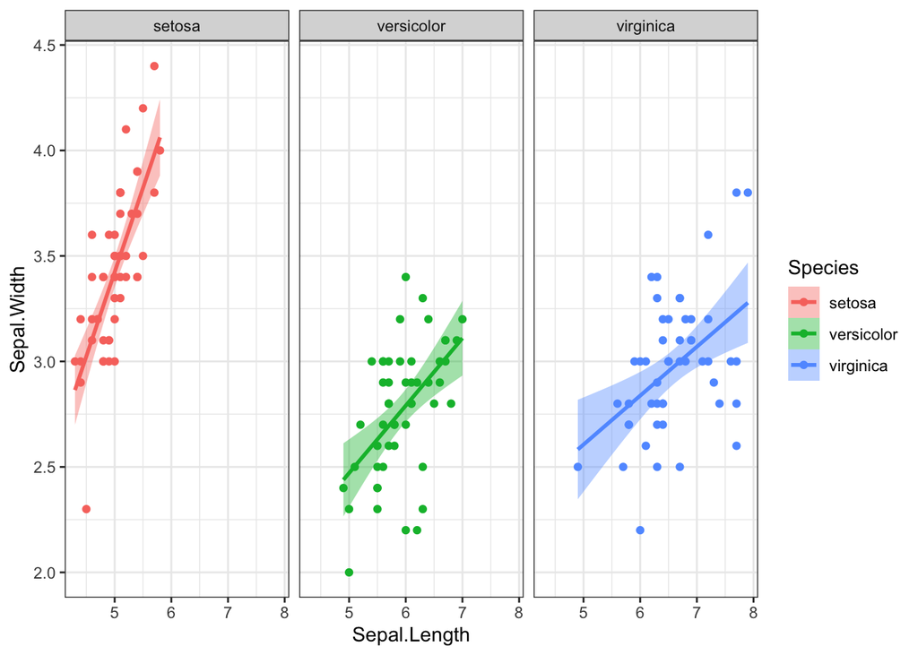

```r
## CHANGE eval to equal to TRUE once you've completed the code chunk
iris %>%
    ggplot(mapping = aes(x = Sepal.Length, y = Sepal.Width)) +
    geom_point(aes(color = Species)) +
    geom_smooth(formula = y~x,
                method = lm,
                aes(col = Species,
                    fill = Species)) +
    facet_wrap(~Species) +
    theme_bw()
```

Now how would you describe the trend between `Sepal.Length` and `Sepal.Width`.

**Author’s Note**: I hope this worksheet has been helpful in learning the basic elements of ggplot! Please let me know if you have any questions or feedback at ane48@pitt.edu. We go over the answers to this worksheet at the next workshop, but if you cannot attend, feel free to email me for the answer key.